# Importing libraries that are required

```python
import pandas as pd
import numpy as np
import seaborn as sns
import matplotlib as mp
```

# Reading data

```python
car = pd.read_csv("D:\PROJECTS\Dataset\data.csv")
```

```python
print("No of data points and columns : ",car.shape)
```

```
No of data points and columns :  (11914, 16)
```

```python
print("Column names : " , car.columns)
```

```
Column names :  Index(['Make', 'Model', 'Year', 'Engine Fuel Type', 'Engine HP',
       'Engine Cylinders', 'Transmission Type', 'Driven_Wheels',
       'Number of Doors', 'Market Category', 'Vehicle Size', 'Vehicle Style',
       'highway MPG', 'city mpg', 'Popularity', 'MSRP'],
      dtype='object')
```

# changing columns names

```python
car.columns=['Make', 'Model', 'Year', 'Engine Fuel Type', 'HP',
       'Cylinders', 'Type', 'DriveMode',
       'Number of Doors', 'Market Category', 'Vehicle Size', 'Vehicle Style',
       'MPG_H', 'MPG_c', 'Popularity', 'price']
```

# Observing top 5 and bottom 5

```python
car.head(5)
```

|  | Make | Model | Year | Engine Fuel Type | HP | Cylinders | Type | DriveMode | Number of Doors | Market Category | Vehicle Size | Vehicle Style | MPG_H | MPG_c | Popularity | price |
| --- | --- | --- | --- | --- | --- | --- | --- | --- | --- | --- | --- | --- | --- | --- | --- | --- |
| 0 | BMW | 1 Series M | 2011 | premium unleaded (required) | 335.0 | 6.0 | MANUAL | rear wheel drive | 2.0 | Factory Tuner,Luxury,High-Performance | Compact | Coupe | 26 | 19 | 3916 | 46135 |
| 1 | BMW | 1 Series | 2011 | premium unleaded (required) | 300.0 | 6.0 | MANUAL | rear wheel drive | 2.0 | Luxury,Performance | Compact | Convertible | 28 | 19 | 3916 | 40650 |
| 2 | BMW | 1 Series | 2011 | premium unleaded (required) | 300.0 | 6.0 | MANUAL | rear wheel drive | 2.0 | Luxury,High-Performance | Compact | Coupe | 28 | 20 | 3916 | 36350 |
| 3 | BMW | 1 Series | 2011 | premium unleaded (required) | 230.0 | 6.0 | MANUAL | rear wheel drive | 2.0 | Luxury,Performance | Compact | Coupe | 28 | 18 | 3916 | 29450 |
| 4 | BMW | 1 Series | 2011 | premium unleaded (required) | 230.0 | 6.0 | MANUAL | rear wheel drive | 2.0 | Luxury | Compact | Convertible | 28 | 18 | 3916 | 34500 |

```python
car.tail(5)
```

|  | Make | Model | Year | Engine Fuel Type | HP | Cylinders | Type | DriveMode | Number of Doors | Market Category | Vehicle Size | Vehicle Style | MPG_H | MPG_c | Popularity | price |
| --- | --- | --- | --- | --- | --- | --- | --- | --- | --- | --- | --- | --- | --- | --- | --- | --- |
| 11909 | Acura | ZDX | 2012 | premium unleaded (required) | 300.0 | 6.0 | AUTOMATIC | all wheel drive | 4.0 | Crossover,Hatchback,Luxury | Midsize | 4dr Hatchback | 23 | 16 | 204 | 46120 |
| 11910 | Acura | ZDX | 2012 | premium unleaded (required) | 300.0 | 6.0 | AUTOMATIC | all wheel drive | 4.0 | Crossover,Hatchback,Luxury | Midsize | 4dr Hatchback | 23 | 16 | 204 | 56670 |
| 11911 | Acura | ZDX | 2012 | premium unleaded (required) | 300.0 | 6.0 | AUTOMATIC | all wheel drive | 4.0 | Crossover,Hatchback,Luxury | Midsize | 4dr Hatchback | 23 | 16 | 204 | 50620 |
| 11912 | Acura | ZDX | 2013 | premium unleaded (recommended) | 300.0 | 6.0 | AUTOMATIC | all wheel drive | 4.0 | Crossover,Hatchback,Luxury | Midsize | 4dr Hatchback | 23 | 16 | 204 | 50920 |
| 11913 | Lincoln | Zephyr | 2006 | regular unleaded | 221.0 | 6.0 | AUTOMATIC | front wheel drive | 4.0 | Luxury | Midsize | Sedan | 26 | 17 | 61 | 28995 |

```python
Makers=car['Make'].value_counts()
MP=car[['Make','price']]
print(MP)
```

```
          Make  price
0          BMW  46135
1          BMW  40650
2          BMW  36350
3          BMW  29450
4          BMW  34500
...        ...    ...
11909    Acura  46120
11910    Acura  56670
11911    Acura  50620
11912    Acura  50920
11913  Lincoln  28995

[11914 rows x 2 columns]
```

# Info about the data frame(with data types of each feature)

```python
car.info()
```

```
<class 'pandas.core.frame.DataFrame'>
RangeIndex: 11914 entries, 0 to 11913
Data columns (total 16 columns):
 #   Column            Non-Null Count  Dtype
---  ------            --------------  -----
 0   Make              11914 non-null  object
 1   Model             11914 non-null  object
 2   Year              11914 non-null  int64
 3   Engine Fuel Type  11911 non-null  object
 4   HP                11845 non-null  float64
 5   Cylinders         11884 non-null  float64
 6   Type              11914 non-null  object
 7   DriveMode         11914 non-null  object
 8   Number of Doors   11908 non-null  float64
 9   Market Category   8172 non-null   object
 10  Vehicle Size      11914 non-null  object
 11  Vehicle Style     11914 non-null  object
 12  MPG_H             11914 non-null  int64
 13  MPG_c             11914 non-null  int64
 14  Popularity        11914 non-null  int64
 15  price             11914 non-null  int64
dtypes: float64(3), int64(5), object(8)
memory usage: 1.5+ MB
```

# Staticstics of features

```python
car.describe()
```

|  | Year | HP | Cylinders | Number of Doors | MPG_H | MPG_c | Popularity | price |
| --- | --- | --- | --- | --- | --- | --- | --- | --- |
| count | 11914.000000 | 11845.00000 | 11884.000000 | 11908.000000 | 11914.000000 | 11914.000000 | 11914.000000 | 1.191400e+04 |
| mean | 2010.384338 | 249.38607 | 5.628829 | 3.436093 | 26.637485 | 19.733255 | 1554.911197 | 4.059474e+04 |
| std | 7.579740 | 109.19187 | 1.780559 | 0.881315 | 8.863001 | 8.987798 | 1441.855347 | 6.010910e+04 |
| min | 1990.000000 | 55.00000 | 0.000000 | 2.000000 | 12.000000 | 7.000000 | 2.000000 | 2.000000e+03 |
| 25% | 2007.000000 | 170.00000 | 4.000000 | 2.000000 | 22.000000 | 16.000000 | 549.000000 | 2.100000e+04 |
| 50% | 2015.000000 | 227.00000 | 6.000000 | 4.000000 | 26.000000 | 18.000000 | 1385.000000 | 2.999500e+04 |
| 75% | 2016.000000 | 300.00000 | 6.000000 | 4.000000 | 30.000000 | 22.000000 | 2009.000000 | 4.223125e+04 |
| max | 2017.000000 | 1001.00000 | 16.000000 | 4.000000 | 354.000000 | 137.000000 | 5657.000000 | 2.065902e+06 |

# Plots to eliminates unwanted features

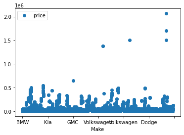

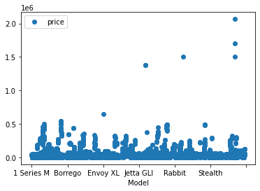

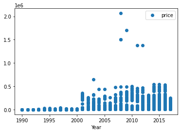

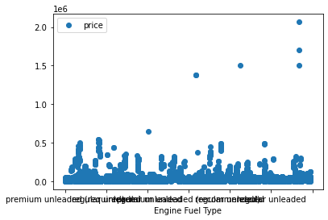

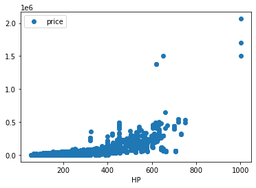

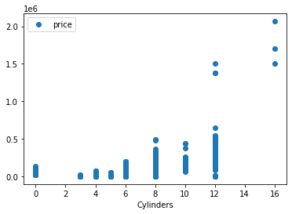

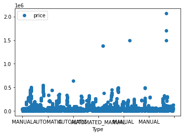

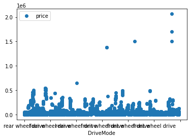

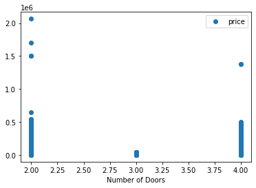

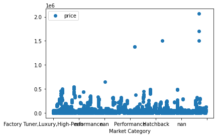

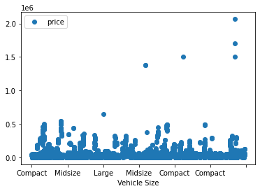

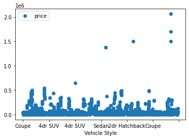

[3 more figures not shown]

```python
for i in car.columns:
    if(i!='price'):
        car.plot(x=i,y='price',style='o')
        #car.plot(x=i,y='price')
```

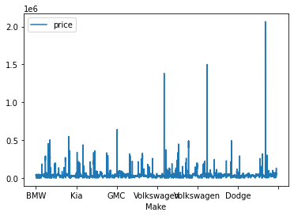

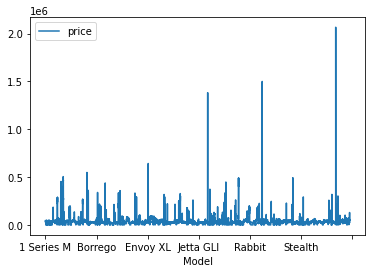

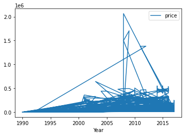

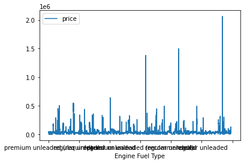

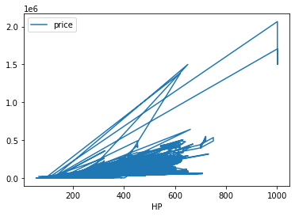

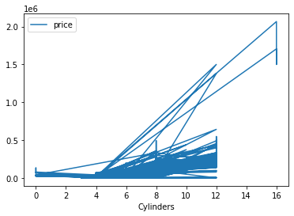

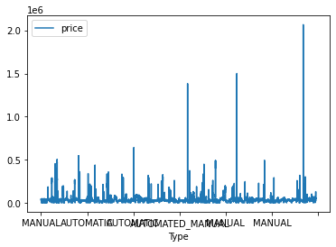

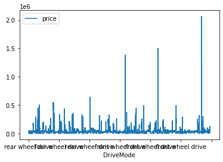

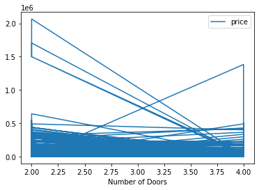

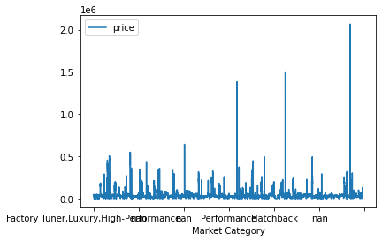

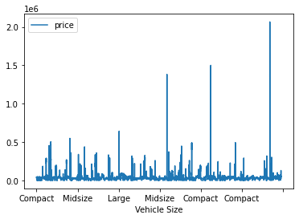

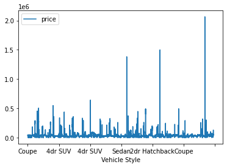

[3 more figures not shown]

```python
for i in car.columns:
    if(i!='price'):
        car.plot(x=i,y='price')
```

**Removing some features based on above 2D plots** We can see every feature is compared with price, now we are removing **"Make,Model,Engine Fuel Type,Type,Market Category,Vehicle size,Vehicle style"** these features. It doesn't mean that they dont pay role in price variation but not significantly.

```python
car=car.drop(['Make', 'Model', 'Engine Fuel Type','Type','Market Category', 'Vehicle Size', 'Vehicle Style'], axis=1)
car.head(5)
```

|  | Year | HP | Cylinders | DriveMode | Number of Doors | MPG_H | MPG_c | Popularity | price |
| --- | --- | --- | --- | --- | --- | --- | --- | --- | --- |
| 0 | 2011 | 335.0 | 6.0 | rear wheel drive | 2.0 | 26 | 19 | 3916 | 46135 |
| 1 | 2011 | 300.0 | 6.0 | rear wheel drive | 2.0 | 28 | 19 | 3916 | 40650 |
| 2 | 2011 | 300.0 | 6.0 | rear wheel drive | 2.0 | 28 | 20 | 3916 | 36350 |
| 3 | 2011 | 230.0 | 6.0 | rear wheel drive | 2.0 | 28 | 18 | 3916 | 29450 |
| 4 | 2011 | 230.0 | 6.0 | rear wheel drive | 2.0 | 28 | 18 | 3916 | 34500 |

**Present Shape of DataFrame car**

```python
car.shape
```

```
(11914, 9)
```

```python
#Columns
car.columns
```

```
Index(['Year', 'HP', 'Cylinders', 'DriveMode', 'Number of Doors', 'MPG_H',
       'MPG_c', 'Popularity', 'price'],
      dtype='object')
```

# Duplicate rows deletion

```python
car[car.duplicated()]
```

|  | Year | HP | Cylinders | DriveMode | Number of Doors | MPG_H | MPG_c | Popularity | price |
| --- | --- | --- | --- | --- | --- | --- | --- | --- | --- |
| 14 | 2013 | 230.0 | 6.0 | rear wheel drive | 2.0 | 28 | 19 | 3916 | 31500 |
| 18 | 1992 | 172.0 | 6.0 | front wheel drive | 4.0 | 24 | 17 | 3105 | 2000 |
| 20 | 1992 | 172.0 | 6.0 | front wheel drive | 4.0 | 24 | 17 | 3105 | 2000 |
| 24 | 1993 | 172.0 | 6.0 | front wheel drive | 4.0 | 24 | 17 | 3105 | 2000 |
| 25 | 1993 | 172.0 | 6.0 | front wheel drive | 4.0 | 24 | 17 | 3105 | 2000 |
| ... | ... | ... | ... | ... | ... | ... | ... | ... | ... |
| 11481 | 1998 | 95.0 | 4.0 | four wheel drive | 2.0 | 26 | 22 | 481 | 2000 |
| 11603 | 2017 | 302.0 | 4.0 | all wheel drive | 4.0 | 29 | 20 | 870 | 46350 |
| 11604 | 2017 | 240.0 | 4.0 | front wheel drive | 4.0 | 30 | 23 | 870 | 40950 |
| 11708 | 2008 | 252.0 | 6.0 | all wheel drive | 4.0 | 22 | 15 | 481 | 29149 |
| 11717 | 2008 | 252.0 | 6.0 | front wheel drive | 4.0 | 22 | 16 | 481 | 27499 |

908 rows × 9 columns

**Found total 908 rows which are duplicates**

```python
car=car.drop_duplicates()
print("after removing duplicates num of rows and columns",car.shape)
```

```
after removing duplicates num of rows and columns (11006, 9)
```

# Now we need to remove null values

```python
#checking for existance of null values
car.isnull().values.any()
```

```
True
```

```python
#No of null values in entire dataframe
car.isnull().sum().sum()
```

```
105
```

```python
#droping null values from dataframe
print("Data frame shape before droping nulls",car.shape)
car=car.dropna()
print("Data frame shape after droping nulls",car.shape)
```

```
Data frame shape before droping nulls (11006, 9)
Data frame shape after droping nulls (10907, 9)
```

# Removing the Outliers

We can detect outliers using boxplots,Zscore,percentiles etc. But here we proceed with boxplots, if it cause difficulty in detection outliers then we move into other methods of finding outliers.

```python
car.columns
```

```
Index(['Year', 'HP', 'Cylinders', 'DriveMode', 'Number of Doors', 'MPG_H',
       'MPG_c', 'Popularity', 'price'],
      dtype='object')
```

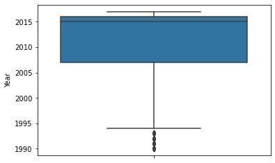

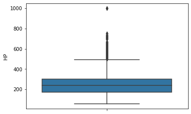

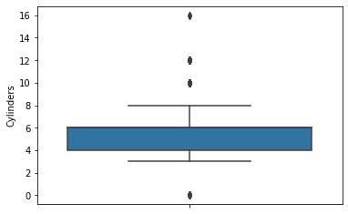

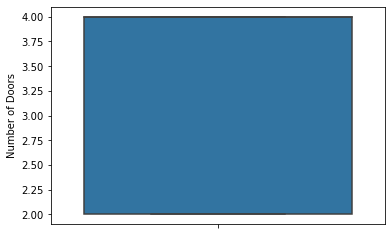

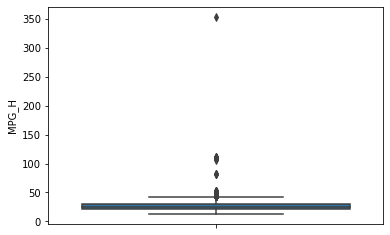

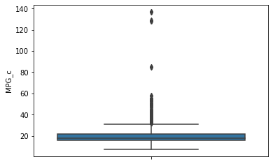

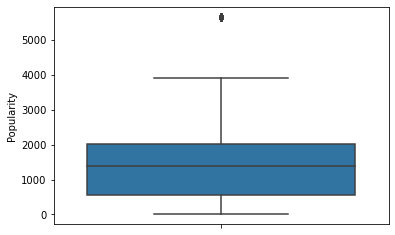

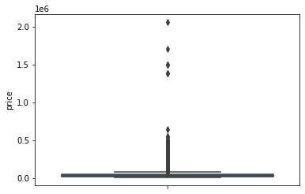

```python
for i in car.columns:
    if (i !='DriveMode'):
        sns.boxplot(y=i,data=car)
        mp.pyplot.show()
    #sns.boxplot(y=car[i])
#sns.boxplot(y=i,data=car)
```

```python
#sns.boxplot(y=car['price'],x=car['DriveMode'])
```

```python
car.columns
```

```
Index(['Year', 'HP', 'Cylinders', 'DriveMode', 'Number of Doors', 'MPG_H',
       'MPG_c', 'Popularity', 'price'],
      dtype='object')
```

```python
for i in car.columns:
    if (i!='DriveMode'):
        Q1 = car[i].quantile(0.25)
        Q3 = car[i].quantile(0.75)
        IQR = Q3 - Q1
        #car = car[~((car[i] < (Q1 - 1.5 * IQR)) |(car[i] > (Q3 + 1.5 * IQR)))][i]
        filters = (car[i] >= Q1 - 1.5 * IQR) & (car[i] <= Q3 + 1.5 *IQR)
        car=car.loc[filters]
```